# Negative Projection Follow-up 1

Kathryn Denning

Originally written June 2018; Updated July 2019

**Variable Glossary:**

*Predictor Variables:*

Condition: What issue participants were given; 1 = political candidate, 2 = racial discrimination, 3 = weed, 4 = PB

Issue_agreement: 1 for condition 1 is Clinton, 2 is Trump, for other three conditions 1 is yes to agreeing with issue, 4 is no to agreeing with issue (AKA ignoring PB, 1 = liberal, 4 = conservative beliefs)

Gender: 1 = male, 2 = female, and 3 = other

Race: 1 = American Indian, 2 = Asian, 3 = African American, 4 = Native Hawaiian/pacific islander, 5 = Caucasian, 6 = Other

Identification: how highly they identify with others who feel the same about them on the issue; 1 = not at all identified, 5 = extremely identified; Identification_c is mean centered

ManCheck: 5 = correct response (all others already removed)

MFQSelf: Scores on MFQ for themselves/the participants; MFQSelf_c is mean centered

*Outcome Variables:*

MFQTarg: Scores on MFQ for target individual who is in out-group/believes the opposite of them on that issue

# Descriptives

## Descriptives for the variables overall

```r
describe(pptnpf1_comb$Identification)
```

```
##    vars    n mean   sd median trimmed  mad min max range  skew kurtosis   se
## X1    1 6725 3.02 1.19      3    3.02 1.48   1   5     4 -0.22    -0.72 0.01
```

```r
describe(pptnpf1_comb$MFQSelf)
```

```
##    vars    n mean   sd median trimmed  mad min max range  skew kurtosis   se
## X1    1 6725 3.89 1.61      4    3.99 1.48   1   6     5 -0.36    -0.98 0.02
```

```r
describe(pptnpf1_comb$MFQTarg)
```

```
##    vars    n mean   sd median trimmed  mad min max range  skew kurtosis   se
## X1    1 6725 4.25 1.56      5    4.41 1.48   1   6     5 -0.61    -0.69 0.02
```

## Mean/SD for MFQ by condition

### MFQ for Self

```r
pptnpf1_comb %>%
  select(Subject, Condition, MFQSelf) %>%
  na.omit() %>%
  group_by(Condition) %>%
  summarize(mean = mean(MFQSelf),
            sd = sd(MFQSelf))
```

```
## # A tibble: 4 x 3
##   Condition  mean    sd
## * <fct>     <dbl> <dbl>
## 1 1          3.88  1.60
## 2 2          3.82  1.61
## 3 3          3.88  1.58
## 4 4          3.98  1.64
```

### MFQ for Target

```r
pptnpf1_comb %>%
  select(Subject, Condition, MFQTarg) %>%
  na.omit() %>%
  group_by(Condition) %>%
  summarize(mean = mean(MFQTarg),
            sd = sd(MFQTarg))
```

```
## # A tibble: 4 x 3
##   Condition  mean    sd
## * <fct>     <dbl> <dbl>
## 1 1          4.14  1.51
## 2 2          4.25  1.57
## 3 3          4.39  1.52
## 4 4          4.23  1.64
```

## Mean/SD for identification by condition

```r
pptnpf1_comb %>%
  select(Subject, Condition, Identification) %>%
  na.omit() %>%
  group_by(Condition) %>%
  summarize(mean = mean(Identification),
            sd = sd(Identification))
```

```
## # A tibble: 4 x 3
##   Condition  mean    sd
## * <fct>     <dbl> <dbl>
## 1 1          3.05 1.04
## 2 2          3.47 0.874
## 3 3          3.06 1.21
## 4 4          2.50 1.36
```

## Reliability for self MFQ

### Overall

```r
MFQself_data <- subset(pptnpf1, select = c(6, 7, 8, 9, 10, 12, 13, 14,
                                           15, 16, 17, 18, 19, 20, 21,
                                           23, 24, 25, 26, 27))
psych::alpha(MFQself_data)
```

```
##
## Reliability analysis
## Call: psych::alpha(x = MFQself_data)
##
##   raw_alpha std.alpha G6(smc) average_r S/N   ase mean   sd median_r
##       0.83      0.83    0.87       0.2 4.9 0.014  3.9 0.65      0.2
##
##  lower alpha upper     95% confidence boundaries
## 0.8 0.83 0.86
##
##  Reliability if an item is dropped:
##             raw_alpha std.alpha G6(smc) average_r S/N alpha se var.r med.r
## MFQ_Self_1       0.83      0.83    0.86      0.20 4.8    0.014 0.019  0.21
## MFQ_Self_2       0.82      0.82    0.86      0.19 4.6    0.014 0.019  0.20
## MFQ_Self_3       0.82      0.82    0.86      0.19 4.6    0.015 0.020  0.19
## MFQ_Self_4       0.82      0.82    0.86      0.19 4.5    0.015 0.022  0.19
## MFQ_Self_5       0.82      0.82    0.86      0.19 4.5    0.015 0.022  0.19
## MFQ_Self_7       0.82      0.82    0.86      0.20 4.6    0.014 0.022  0.20
## MFQ_Self_8       0.83      0.83    0.86      0.20 4.7    0.014 0.021  0.21
## MFQ_Self_9       0.82      0.82    0.86      0.19 4.5    0.015 0.023  0.19
## MFQ_Self_10      0.82      0.83    0.87      0.20 4.7    0.014 0.022  0.20
## MFQ_Self_11      0.82      0.82    0.86      0.20 4.6    0.015 0.023  0.20
## MFQ_Self_12      0.83      0.82    0.86      0.20 4.7    0.014 0.021  0.21
## MFQ_Self_13      0.82      0.82    0.86      0.20 4.7    0.014 0.021  0.20
## MFQ_Self_15      0.83      0.83    0.87      0.20 4.9    0.014 0.019  0.20
## MFQ_Self_16      0.82      0.82    0.86      0.19 4.5    0.015 0.022  0.19
## MFQ_Self_17      0.82      0.82    0.86      0.20 4.6    0.015 0.023  0.19
## MFQ_Self_19      0.83      0.83    0.87      0.20 4.9    0.014 0.021  0.21
## MFQ_Self_20      0.82      0.82    0.86      0.20 4.7    0.014 0.023  0.20
## MFQ_Self_21      0.82      0.82    0.86      0.20 4.6    0.015 0.023  0.19
## MFQ_Self_22      0.83      0.83    0.87      0.20 4.8    0.014 0.020  0.20
## MFQ_Self_23      0.82      0.82    0.86      0.20 4.6    0.015 0.022  0.19
##
##  Item statistics
##               n raw.r std.r r.cor r.drop mean  sd
## MFQ_Self_1  314  0.39  0.43  0.41   0.30  4.8 1.2
## MFQ_Self_2  314  0.48  0.52  0.52   0.41  4.8 1.1
## MFQ_Self_3  313  0.58  0.55  0.53   0.50  2.7 1.5
## MFQ_Self_4  314  0.62  0.61  0.59   0.55  3.6 1.4
## MFQ_Self_5  313  0.62  0.60  0.58   0.54  3.8 1.5
```

[output cut: 23 more lines]

```
## MFQ_Self_7  0.04 0.04 0.12 0.31 0.31 0.18 0.00
## MFQ_Self_8  0.01 0.03 0.08 0.25 0.38 0.25 0.01
## MFQ_Self_9  0.06 0.08 0.20 0.25 0.27 0.13 0.00
## MFQ_Self_10 0.18 0.23 0.25 0.20 0.11 0.04 0.00
## MFQ_Self_11 0.08 0.16 0.17 0.29 0.18 0.13 0.00
## MFQ_Self_12 0.03 0.01 0.07 0.21 0.40 0.27 0.00
## MFQ_Self_13 0.01 0.03 0.07 0.15 0.29 0.46 0.00
## MFQ_Self_15 0.23 0.27 0.17 0.18 0.09 0.06 0.01
## MFQ_Self_16 0.02 0.08 0.15 0.34 0.22 0.19 0.01
## MFQ_Self_17 0.05 0.13 0.23 0.27 0.21 0.10 0.00
## MFQ_Self_19 0.02 0.04 0.09 0.19 0.24 0.42 0.01
## MFQ_Self_20 0.01 0.06 0.15 0.21 0.35 0.22 0.01
## MFQ_Self_21 0.07 0.18 0.22 0.24 0.16 0.11 0.00
## MFQ_Self_22 0.28 0.17 0.22 0.19 0.08 0.06 0.00
## MFQ_Self_23 0.18 0.19 0.25 0.23 0.09 0.05 0.00
```

### Harm

```r
harm_self <- MFQself_data %>%
  select(MFQ_Self_1, MFQ_Self_7, MFQ_Self_12, MFQ_Self_19)
psych::alpha(harm_self)
```

```
##
## Reliability analysis
## Call: psych::alpha(x = harm_self)
##
##   raw_alpha std.alpha G6(smc) average_r S/N   ase mean   sd median_r
##       0.65      0.65     0.6      0.32 1.9 0.033  4.7 0.86     0.33
##
##  lower alpha upper     95% confidence boundaries
## 0.58 0.65 0.71
##
##  Reliability if an item is dropped:
##             raw_alpha std.alpha G6(smc) average_r S/N alpha se  var.r med.r
## MFQ_Self_1       0.51      0.51    0.43      0.26 1.1    0.049 0.0156  0.33
## MFQ_Self_7       0.62      0.63    0.54      0.36 1.7    0.037 0.0107  0.33
## MFQ_Self_12      0.51      0.51    0.44      0.26 1.1    0.048 0.0188  0.27
## MFQ_Self_19      0.67      0.67    0.58      0.40 2.0    0.033 0.0047  0.39
##
##  Item statistics
##               n raw.r std.r r.cor r.drop mean  sd
## MFQ_Self_1  314  0.76  0.76  0.66   0.53  4.8 1.2
## MFQ_Self_7  314  0.66  0.66  0.47   0.37  4.4 1.2
## MFQ_Self_12 314  0.75  0.76  0.66   0.53  4.8 1.1
## MFQ_Self_19 312  0.63  0.61  0.39   0.31  4.9 1.3
##
## Non missing response frequency for each item
##                1    2    3    4    5    6 miss
## MFQ_Self_1  0.02 0.05 0.06 0.18 0.34 0.34 0.00
## MFQ_Self_7  0.04 0.04 0.12 0.31 0.31 0.18 0.00
## MFQ_Self_12 0.03 0.01 0.07 0.21 0.40 0.27 0.00
## MFQ_Self_19 0.02 0.04 0.09 0.19 0.24 0.42 0.01
```

### Fairness

```r
fair_self <- MFQself_data %>%
  select(MFQ_Self_2, MFQ_Self_8, MFQ_Self_13, MFQ_Self_20)
psych::alpha(fair_self)
```

```
##
## Reliability analysis
## Call: psych::alpha(x = fair_self)
##
##   raw_alpha std.alpha G6(smc) average_r S/N   ase mean   sd median_r
##       0.61      0.62    0.58      0.29 1.6 0.036  4.8 0.79     0.26
##
##  lower alpha upper     95% confidence boundaries
## 0.54 0.61 0.68
##
##  Reliability if an item is dropped:
##             raw_alpha std.alpha G6(smc) average_r  S/N alpha se  var.r med.r
## MFQ_Self_2       0.47      0.46    0.38      0.22 0.86    0.052 0.0092  0.19
## MFQ_Self_8       0.58      0.58    0.50      0.32 1.40    0.042 0.0169  0.33
## MFQ_Self_13      0.50      0.51    0.43      0.25 1.02    0.050 0.0234  0.18
## MFQ_Self_20      0.62      0.62    0.55      0.35 1.63    0.037 0.0206  0.43
##
##  Item statistics
##               n raw.r std.r r.cor r.drop mean  sd
## MFQ_Self_2  314  0.75  0.75  0.66   0.50  4.8 1.1
## MFQ_Self_8  311  0.64  0.65  0.46   0.35  4.7 1.1
## MFQ_Self_13 313  0.72  0.72  0.59   0.45  5.1 1.1
## MFQ_Self_20 312  0.64  0.61  0.38   0.29  4.5 1.2
##
## Non missing response frequency for each item
##                1    2    3    4    5    6 miss
## MFQ_Self_2  0.02 0.03 0.06 0.21 0.38 0.30 0.00
## MFQ_Self_8  0.01 0.03 0.08 0.25 0.38 0.25 0.01
## MFQ_Self_13 0.01 0.03 0.07 0.15 0.29 0.46 0.00
## MFQ_Self_20 0.01 0.06 0.15 0.21 0.35 0.22 0.01
```

### In-group

```r
ingroup_self <- MFQself_data %>%
  select(MFQ_Self_3, MFQ_Self_9, MFQ_Self_15, MFQ_Self_21)
psych::alpha(ingroup_self)
```

```
##
## Reliability analysis
## Call: psych::alpha(x = ingroup_self)
##
##   raw_alpha std.alpha G6(smc) average_r S/N   ase mean sd median_r
##       0.64      0.64    0.58      0.31 1.8 0.033  3.3  1     0.33
##
##  lower alpha upper     95% confidence boundaries
## 0.57 0.64 0.7
##
##  Reliability if an item is dropped:
##             raw_alpha std.alpha G6(smc) average_r S/N alpha se   var.r med.r
## MFQ_Self_3       0.53      0.53    0.44      0.27 1.1    0.046 0.00959  0.32
## MFQ_Self_9       0.60      0.60    0.51      0.34 1.5    0.039 0.00254  0.32
## MFQ_Self_15      0.59      0.59    0.49      0.32 1.4    0.040 0.00042  0.33
## MFQ_Self_21      0.56      0.56    0.48      0.30 1.3    0.043 0.01531  0.34
##
##  Item statistics
##               n raw.r std.r r.cor r.drop mean  sd
## MFQ_Self_3  313  0.74  0.73  0.60   0.48  2.7 1.5
## MFQ_Self_9  314  0.64  0.66  0.47   0.37  4.0 1.4
## MFQ_Self_15 310  0.69  0.68  0.51   0.40  2.8 1.5
## MFQ_Self_21 314  0.71  0.70  0.54   0.43  3.6 1.4
##
## Non missing response frequency for each item
##                1    2    3    4    5    6 miss
## MFQ_Self_3  0.30 0.20 0.20 0.18 0.08 0.04 0.00
## MFQ_Self_9  0.06 0.08 0.20 0.25 0.27 0.13 0.00
## MFQ_Self_15 0.23 0.27 0.17 0.18 0.09 0.06 0.01
## MFQ_Self_21 0.07 0.18 0.22 0.24 0.16 0.11 0.00
```

### Authority

```r
authority_self <- MFQself_data %>%
  select(MFQ_Self_4, MFQ_Self_10, MFQ_Self_16, MFQ_Self_22)
psych::alpha(authority_self)
```

```
##
## Reliability analysis
## Call: psych::alpha(x = authority_self)
##
##   raw_alpha std.alpha G6(smc) average_r S/N   ase mean   sd median_r
##        0.6      0.61    0.55      0.28 1.5 0.037  3.4 0.94     0.24
##
##  lower alpha upper     95% confidence boundaries
## 0.53 0.6 0.67
##
##  Reliability if an item is dropped:
##             raw_alpha std.alpha G6(smc) average_r  S/N alpha se   var.r med.r
## MFQ_Self_4       0.50      0.50    0.41      0.25 1.00    0.049 0.00678  0.21
## MFQ_Self_10      0.59      0.60    0.52      0.33 1.50    0.041 0.01362  0.34
## MFQ_Self_16      0.46      0.47    0.37      0.23 0.88    0.052 0.00081  0.21
## MFQ_Self_22      0.56      0.56    0.48      0.30 1.29    0.043 0.01651  0.26
##
##  Item statistics
##               n raw.r std.r r.cor r.drop mean  sd
## MFQ_Self_4  314  0.70  0.71  0.57   0.42  3.6 1.4
## MFQ_Self_10 314  0.61  0.61  0.38   0.30  2.9 1.4
## MFQ_Self_16 312  0.72  0.73  0.62   0.47  4.2 1.3
## MFQ_Self_22 314  0.68  0.65  0.45   0.34  2.8 1.5
##
## Non missing response frequency for each item
##                1    2    3    4    5    6 miss
## MFQ_Self_4  0.08 0.15 0.25 0.24 0.20 0.08 0.00
## MFQ_Self_10 0.18 0.23 0.25 0.20 0.11 0.04 0.00
## MFQ_Self_16 0.02 0.08 0.15 0.34 0.22 0.19 0.01
## MFQ_Self_22 0.28 0.17 0.22 0.19 0.08 0.06 0.00
```

### Purity

```r
purity_self <- MFQself_data %>%
  select(MFQ_Self_5, MFQ_Self_11, MFQ_Self_17, MFQ_Self_23)
psych::alpha(purity_self)
```

```
##
## Reliability analysis
## Call: psych::alpha(x = purity_self)
##
##   raw_alpha std.alpha G6(smc) average_r S/N   ase mean   sd median_r
##       0.62      0.62    0.56      0.29 1.6 0.035  3.6 0.98     0.28
##
##  lower alpha upper     95% confidence boundaries
## 0.55 0.62 0.69
##
##  Reliability if an item is dropped:
##             raw_alpha std.alpha G6(smc) average_r S/N alpha se  var.r med.r
## MFQ_Self_5       0.58      0.58    0.48      0.31 1.4    0.042 0.0052  0.33
## MFQ_Self_11      0.53      0.53    0.43      0.27 1.1    0.046 0.0022  0.26
## MFQ_Self_17      0.52      0.52    0.42      0.26 1.1    0.047 0.0011  0.26
## MFQ_Self_23      0.57      0.57    0.47      0.31 1.3    0.042 0.0047  0.30
##
##  Item statistics
##               n raw.r std.r r.cor r.drop mean  sd
## MFQ_Self_5  313  0.67  0.66  0.46   0.36  3.8 1.5
## MFQ_Self_11 314  0.70  0.70  0.54   0.42  3.7 1.5
## MFQ_Self_17 313  0.69  0.71  0.57   0.44  3.8 1.3
## MFQ_Self_23 314  0.66  0.67  0.47   0.37  3.0 1.4
##
## Non missing response frequency for each item
##                1    2    3    4    5    6 miss
## MFQ_Self_5  0.10 0.13 0.16 0.25 0.21 0.14    0
## MFQ_Self_11 0.08 0.16 0.17 0.29 0.18 0.13    0
## MFQ_Self_17 0.05 0.13 0.23 0.27 0.21 0.10    0
## MFQ_Self_23 0.18 0.19 0.25 0.23 0.09 0.05    0
```

## Reliability for target MFQ

### Overall

```r
# Accidentally skipped "14" when labeling the items in the dataset and did not want to re-work things in case I introduced a coding error
MFQtarg_data <- subset(pptnpf1,select = c(MFQ_Targ_1, MFQ_Targ_2, MFQ_Targ_3,
                                        MFQ_Targ_4, MFQ_Targ_5, MFQ_Targ_7,
                                        MFQ_Targ_8, MFQ_Targ_9, MFQ_Targ_10,
                                        MFQ_Targ_11, MFQ_Targ_12, MFQ_Targ_13,
                                        MFQ_Targ_15, MFQ_Targ_16, MFQ_Targ_17,
                                        MFQ_Targ_19, MFQ_Targ_20, MFQ_Targ_21,
                                        MFQ_Targ_22, MFQ_Targ_23))
MFQtarg_data <- na.omit(MFQtarg_data)
psych::alpha(MFQtarg_data)
```

```
##
## Reliability analysis
## Call: psych::alpha(x = MFQtarg_data)
##
##   raw_alpha std.alpha G6(smc) average_r S/N   ase mean   sd median_r
##       0.87      0.87    0.92      0.25 6.6 0.012  4.3 0.79     0.26
##
##  lower alpha upper     95% confidence boundaries
## 0.84 0.87 0.89
##
##  Reliability if an item is dropped:
##             raw_alpha std.alpha G6(smc) average_r S/N alpha se var.r med.r
## MFQ_Targ_1       0.86      0.86    0.92      0.25 6.2    0.012 0.058  0.27
## MFQ_Targ_2       0.87      0.87    0.92      0.26 6.6    0.011 0.054  0.27
## MFQ_Targ_3       0.86      0.87    0.92      0.25 6.4    0.012 0.060  0.26
## MFQ_Targ_4       0.85      0.86    0.92      0.24 6.0    0.013 0.063  0.25
## MFQ_Targ_5       0.85      0.86    0.92      0.24 6.0    0.013 0.065  0.26
## MFQ_Targ_7       0.86      0.86    0.92      0.25 6.3    0.012 0.058  0.27
## MFQ_Targ_8       0.86      0.86    0.92      0.25 6.4    0.012 0.060  0.27
## MFQ_Targ_9       0.86      0.86    0.92      0.24 6.2    0.012 0.067  0.25
## MFQ_Targ_10      0.86      0.86    0.92      0.25 6.3    0.012 0.062  0.26
## MFQ_Targ_11      0.85      0.86    0.92      0.24 6.0    0.013 0.064  0.26
## MFQ_Targ_12      0.86      0.87    0.92      0.25 6.4    0.012 0.057  0.27
## MFQ_Targ_13      0.86      0.87    0.92      0.25 6.4    0.012 0.057  0.27
## MFQ_Targ_15      0.86      0.87    0.92      0.25 6.5    0.012 0.056  0.26
## MFQ_Targ_16      0.86      0.86    0.91      0.24 6.0    0.013 0.061  0.25
## MFQ_Targ_17      0.86      0.86    0.92      0.24 6.2    0.012 0.064  0.26
## MFQ_Targ_19      0.86      0.87    0.92      0.25 6.5    0.012 0.063  0.27
## MFQ_Targ_20      0.86      0.86    0.92      0.25 6.2    0.012 0.067  0.26
## MFQ_Targ_21      0.86      0.86    0.92      0.24 6.2    0.012 0.066  0.25
## MFQ_Targ_22      0.87      0.87    0.92      0.26 6.6    0.011 0.056  0.26
## MFQ_Targ_23      0.86      0.86    0.92      0.25 6.2    0.012 0.061  0.25
##
##  Item statistics
##               n raw.r std.r r.cor r.drop mean  sd
## MFQ_Targ_1  307  0.56  0.56  0.56   0.49  4.4 1.5
## MFQ_Targ_2  307  0.39  0.40  0.38   0.30  4.1 1.6
## MFQ_Targ_3  307  0.48  0.47  0.44   0.40  4.1 1.5
## MFQ_Targ_4  307  0.66  0.66  0.65   0.61  4.4 1.5
## MFQ_Targ_5  307  0.68  0.68  0.66   0.62  4.4 1.5
```

[output cut: 23 more lines]

```
## MFQ_Targ_7  0.07 0.11 0.17 0.20 0.24 0.21    0
## MFQ_Targ_8  0.06 0.11 0.11 0.26 0.26 0.20    0
## MFQ_Targ_9  0.05 0.08 0.14 0.24 0.29 0.19    0
## MFQ_Targ_10 0.07 0.09 0.12 0.21 0.25 0.24    0
## MFQ_Targ_11 0.06 0.10 0.14 0.23 0.22 0.24    0
## MFQ_Targ_12 0.05 0.09 0.11 0.24 0.24 0.27    0
## MFQ_Targ_13 0.03 0.10 0.17 0.23 0.19 0.27    0
## MFQ_Targ_15 0.08 0.09 0.09 0.22 0.22 0.29    0
## MFQ_Targ_16 0.03 0.07 0.07 0.15 0.26 0.43    0
## MFQ_Targ_17 0.04 0.10 0.12 0.22 0.24 0.28    0
## MFQ_Targ_19 0.04 0.07 0.09 0.20 0.23 0.36    0
## MFQ_Targ_20 0.02 0.05 0.11 0.20 0.28 0.35    0
## MFQ_Targ_21 0.03 0.07 0.12 0.20 0.28 0.31    0
## MFQ_Targ_22 0.15 0.12 0.11 0.21 0.18 0.21    0
## MFQ_Targ_23 0.07 0.06 0.13 0.20 0.23 0.31    0
```

### Harm

```r
harm_targ <- MFQtarg_data %>%
  select(MFQ_Targ_1, MFQ_Targ_7, MFQ_Targ_12, MFQ_Targ_19)
psych::alpha(harm_targ)
```

```
##
## Reliability analysis
## Call: psych::alpha(x = harm_targ)
##
##   raw_alpha std.alpha G6(smc) average_r S/N   ase mean  sd median_r
##       0.84      0.84    0.82      0.58 5.4 0.015  4.4 1.2     0.58
##
##  lower alpha upper     95% confidence boundaries
## 0.82 0.84 0.87
##
##  Reliability if an item is dropped:
##             raw_alpha std.alpha G6(smc) average_r S/N alpha se   var.r med.r
## MFQ_Targ_1       0.77      0.77    0.71      0.53 3.4    0.023 0.01503  0.50
## MFQ_Targ_7       0.78      0.78    0.73      0.55 3.6    0.022 0.01672  0.50
## MFQ_Targ_12      0.77      0.77    0.72      0.53 3.4    0.023 0.02583  0.45
## MFQ_Targ_19      0.87      0.87    0.82      0.69 6.7    0.013 0.00059  0.69
##
##  Item statistics
##               n raw.r std.r r.cor r.drop mean  sd
## MFQ_Targ_1  307  0.87  0.86  0.82   0.75  4.4 1.5
## MFQ_Targ_7  307  0.86  0.85  0.80   0.72  4.1 1.5
## MFQ_Targ_12 307  0.86  0.87  0.81   0.75  4.3 1.5
## MFQ_Targ_19 307  0.72  0.72  0.55   0.51  4.6 1.4
##
## Non missing response frequency for each item
##                1    2    3    4    5    6 miss
## MFQ_Targ_1  0.06 0.07 0.10 0.19 0.30 0.28    0
## MFQ_Targ_7  0.07 0.11 0.17 0.20 0.24 0.21    0
## MFQ_Targ_12 0.05 0.09 0.11 0.24 0.24 0.27    0
## MFQ_Targ_19 0.04 0.07 0.09 0.20 0.23 0.36    0
```

### Fairness

```r
fair_targ <- MFQtarg_data %>%
  select(MFQ_Targ_2, MFQ_Targ_8, MFQ_Targ_13, MFQ_Targ_20)
psych::alpha(fair_targ)
```

```
##
## Reliability analysis
## Call: psych::alpha(x = fair_targ)
##
##   raw_alpha std.alpha G6(smc) average_r S/N  ase mean  sd median_r
##       0.78      0.77    0.76      0.46 3.4 0.02  4.3 1.1     0.48
##
##  lower alpha upper     95% confidence boundaries
## 0.74 0.78 0.82
##
##  Reliability if an item is dropped:
##             raw_alpha std.alpha G6(smc) average_r S/N alpha se  var.r med.r
## MFQ_Targ_2       0.68      0.68    0.61      0.41 2.1    0.031 0.0202  0.40
## MFQ_Targ_8       0.70      0.69    0.67      0.43 2.2    0.030 0.0536  0.40
## MFQ_Targ_13      0.65      0.64    0.59      0.37 1.7    0.034 0.0482  0.27
## MFQ_Targ_20      0.83      0.83    0.77      0.62 4.8    0.017 0.0033  0.62
##
##  Item statistics
##               n raw.r std.r r.cor r.drop mean  sd
## MFQ_Targ_2  307  0.84  0.81  0.77   0.66  4.1 1.6
## MFQ_Targ_8  307  0.80  0.80  0.70   0.63  4.1 1.5
## MFQ_Targ_13 307  0.86  0.85  0.81   0.72  4.3 1.4
## MFQ_Targ_20 307  0.58  0.61  0.40   0.34  4.7 1.3
##
## Non missing response frequency for each item
##                1    2    3    4    5    6 miss
## MFQ_Targ_2  0.07 0.16 0.14 0.16 0.23 0.24    0
## MFQ_Targ_8  0.06 0.11 0.11 0.26 0.26 0.20    0
## MFQ_Targ_13 0.03 0.10 0.17 0.23 0.19 0.27    0
## MFQ_Targ_20 0.02 0.05 0.11 0.20 0.28 0.35    0
```

### In-group

```r
ingroup_targ <- MFQtarg_data %>%
  select(MFQ_Targ_3, MFQ_Targ_9, MFQ_Targ_15, MFQ_Targ_21)
psych::alpha(ingroup_targ)
```

```
##
## Reliability analysis
## Call: psych::alpha(x = ingroup_targ)
##
##   raw_alpha std.alpha G6(smc) average_r S/N  ase mean sd median_r
##       0.68      0.68    0.64      0.35 2.1 0.03  4.3  1     0.32
##
##  lower alpha upper     95% confidence boundaries
## 0.62 0.68 0.74
##
##  Reliability if an item is dropped:
##             raw_alpha std.alpha G6(smc) average_r S/N alpha se  var.r med.r
## MFQ_Targ_3       0.54      0.54    0.45      0.28 1.2    0.045 0.0027  0.28
## MFQ_Targ_9       0.67      0.66    0.59      0.40 2.0    0.032 0.0190  0.34
## MFQ_Targ_15      0.58      0.58    0.49      0.32 1.4    0.041 0.0022  0.30
## MFQ_Targ_21      0.66      0.65    0.59      0.39 1.9    0.034 0.0263  0.37
##
##  Item statistics
##               n raw.r std.r r.cor r.drop mean  sd
## MFQ_Targ_3  307  0.78  0.78  0.70   0.58  4.1 1.5
## MFQ_Targ_9  307  0.65  0.66  0.46   0.38  4.2 1.4
## MFQ_Targ_15 307  0.76  0.74  0.64   0.51  4.3 1.6
## MFQ_Targ_21 307  0.66  0.67  0.48   0.40  4.5 1.4
##
## Non missing response frequency for each item
##                1    2    3    4    5    6 miss
## MFQ_Targ_3  0.06 0.09 0.19 0.21 0.25 0.20    0
## MFQ_Targ_9  0.05 0.08 0.14 0.24 0.29 0.19    0
## MFQ_Targ_15 0.08 0.09 0.09 0.22 0.22 0.29    0
## MFQ_Targ_21 0.03 0.07 0.12 0.20 0.28 0.31    0
```

### Authority

```r
authority_targ <- MFQtarg_data %>%
  select(MFQ_Targ_4, MFQ_Targ_10, MFQ_Targ_16, MFQ_Targ_22)
psych::alpha(authority_targ)
```

```
##
## Reliability analysis
## Call: psych::alpha(x = authority_targ)
##
##   raw_alpha std.alpha G6(smc) average_r S/N   ase mean  sd median_r
##       0.75      0.76    0.73      0.44 3.2 0.024  4.3 1.2      0.4
##
##  lower alpha upper     95% confidence boundaries
## 0.7 0.75 0.8
##
##  Reliability if an item is dropped:
##             raw_alpha std.alpha G6(smc) average_r S/N alpha se  var.r med.r
## MFQ_Targ_4       0.67      0.67    0.58      0.40 2.0    0.033 0.0018  0.38
## MFQ_Targ_10      0.73      0.74    0.69      0.49 2.9    0.028 0.0272  0.45
## MFQ_Targ_16      0.64      0.65    0.55      0.38 1.8    0.035 0.0013  0.37
## MFQ_Targ_22      0.74      0.74    0.69      0.49 2.9    0.026 0.0243  0.42
##
##  Item statistics
##               n raw.r std.r r.cor r.drop mean  sd
## MFQ_Targ_4  307  0.78  0.80  0.74   0.60  4.4 1.5
## MFQ_Targ_10 307  0.72  0.71  0.54   0.48  4.2 1.5
## MFQ_Targ_16 307  0.81  0.82  0.77   0.65  4.8 1.4
## MFQ_Targ_22 307  0.74  0.71  0.55   0.48  3.8 1.7
##
## Non missing response frequency for each item
##                1    2    3    4    5    6 miss
## MFQ_Targ_4  0.06 0.06 0.10 0.20 0.30 0.28    0
## MFQ_Targ_10 0.07 0.09 0.12 0.21 0.25 0.24    0
## MFQ_Targ_16 0.03 0.07 0.07 0.15 0.26 0.43    0
## MFQ_Targ_22 0.15 0.12 0.11 0.21 0.18 0.21    0
```

### Purity

```r
purity_targ <- MFQtarg_data %>%
  select(MFQ_Targ_5, MFQ_Targ_11, MFQ_Targ_17, MFQ_Targ_23)
psych::alpha(purity_targ)
```

```
##
## Reliability analysis
## Call: psych::alpha(x = purity_targ)
##
##   raw_alpha std.alpha G6(smc) average_r S/N   ase mean  sd median_r
##       0.78      0.78    0.73      0.47 3.5 0.021  4.3 1.2     0.47
##
##  lower alpha upper     95% confidence boundaries
## 0.74 0.78 0.82
##
##  Reliability if an item is dropped:
##             raw_alpha std.alpha G6(smc) average_r S/N alpha se  var.r med.r
## MFQ_Targ_5       0.73      0.74    0.66      0.48 2.8    0.026 0.0050  0.51
## MFQ_Targ_11      0.71      0.71    0.63      0.45 2.5    0.029 0.0050  0.42
## MFQ_Targ_17      0.71      0.71    0.63      0.45 2.5    0.029 0.0047  0.42
## MFQ_Targ_23      0.73      0.73    0.66      0.48 2.8    0.026 0.0051  0.51
##
##  Item statistics
##               n raw.r std.r r.cor r.drop mean  sd
## MFQ_Targ_5  307  0.76  0.76  0.63   0.56  4.4 1.5
## MFQ_Targ_11 307  0.79  0.79  0.69   0.60  4.2 1.5
## MFQ_Targ_17 307  0.78  0.79  0.69   0.60  4.4 1.4
## MFQ_Targ_23 307  0.76  0.76  0.64   0.56  4.4 1.5
##
## Non missing response frequency for each item
##                1    2    3    4    5    6 miss
## MFQ_Targ_5  0.06 0.08 0.11 0.19 0.26 0.30    0
## MFQ_Targ_11 0.06 0.10 0.14 0.23 0.22 0.24    0
## MFQ_Targ_17 0.04 0.10 0.12 0.22 0.24 0.28    0
## MFQ_Targ_23 0.07 0.06 0.13 0.20 0.23 0.31    0
```

# Demographics

## Number of participants - Overall

```r
pptnpf1_comb  %>%
  select(Subject) %>%
  unique() %>%
  nrow()
```

```
## [1] 306
```

## Number of participants - By condition

```r
pptnpf1_comb %>%
  select(Subject, Condition) %>%
  mutate(Condition = recode(Condition,
                            `1` = "Political candidate",
                            `2` = "Racial disadvantage",
                            `3` = "Marijuana legalization",
                            `4` = "Peanut butter preference")) %>%
  group_by(Condition) %>%
  unique() %>%
  count()
```

```
## # A tibble: 4 x 2
## # Groups:   Condition [4]
##   Condition                    n
##   <fct>                    <int>
## 1 Political candidate         76
## 2 Racial disadvantage         74
## 3 Marijuana legalization      81
## 4 Peanut butter preference    75
```

## Number of participants - By gender

```r
pptnpf1_comb %>%
  select(Subject, Gender) %>%
    mutate(Gender = recode(Gender,
                         `1` = "Male",
                         `2` = "Female")) %>%
  group_by(Gender) %>%
  unique() %>%
  count()
```

```
## # A tibble: 2 x 2
## # Groups:   Gender [2]
##   Gender     n
##   <fct>  <int>
## 1 Male      91
## 2 Female   215
```

## Number of participants - By race

```r
pptnpf1_comb %>%
  select(Subject, MFQTarg, MFQSelf_c, Identification_c, Condition, Race) %>%
  na.omit() %>%
  select(Subject, Race) %>%
  unique() %>%
  group_by(Race) %>%
  count()
```

```
## # A tibble: 5 x 2
## # Groups:   Race [5]
##   Race      n
##   <fct> <int>
## 1 2        59
## 2 3        14
## 3 4         8
## 4 5       194
## 5 6        32
```

### Caucasian Percentage

```r
white <- (194/306)*100
white
```

```
## [1] 63.39869
```

### Asian Percentage

```r
asian <- (59/306)*100
asian
```

```
## [1] 19.28105
```

### Identified as “Other” Percentage

```r
other <- (32/306)*100
other
```

```
## [1] 10.45752
```

### Black Percentage

```r
black <- (14/306)*100
black
```

```
## [1] 4.575163
```

### Hawaiian/Pacific Islander Percentage

```r
hawaiipacific <- (8/306)*100
hawaiipacific
```

```
## [1] 2.614379
```

## Age

```r
pptnpf1_comb %>%
  select(Subject, MFQTarg, MFQSelf_c, Identification_c, Condition, Age) %>%
  na.omit() %>%
  select(Subject, Age) %>%
  unique() %>%
  summarize(mean(Age)) %>%
  summarize(Mean = mean(`mean(Age)`),
            SD = sd(`mean(Age)`))
```

```
## # A tibble: 1 x 2
##    Mean    SD
##   <dbl> <dbl>
## 1  19.6  2.17
```

# Model

## Contrast codes

```r
#contrasts assigned to condition
contrasts(pptnpf1_comb$Condition)
```

[output not shown]

## Results

```r
#Model with random slopes for MFQ
Model1_randomslopes <- lmer(MFQTarg ~ MFQSelf_c*Identification_c*Condition +
                              (MFQSelf_c|Subject),
                            data = pptnpf1_comb, na.action = na.omit)

tab_model(Model1_randomslopes,
          title = "Effects of predictors and interactions on projection")
```

Effects of predictors and interactions on projection

|  | MFQ Targ |  |  |
| --- | --- | --- | --- |
| Predictors | Estimates | CI | p |
| (Intercept) | 4.19 | 4.11 – 4.27 | **<0.001** |
| MFQSelf_c | 0.20 | 0.16 – 0.25 | **<0.001** |
| Identification_c | 0.12 | 0.04 – 0.19 | **0.003** |
| ConditionPRWvPB | 0.01 | -0.04 – 0.07 | 0.624 |
| ConditionPRvW | 0.10 | 0.03 – 0.16 | **0.004** |
| ConditionPvR | 0.00 | -0.12 – 0.13 | 0.975 |
| MFQSelf_c * Identification_c | -0.09 | -0.13 – -0.05 | **<0.001** |
| MFQSelf_c * ConditionPRWvPB | 0.07 | 0.04 – 0.10 | **<0.001** |
| MFQSelf_c * ConditionPRvW | 0.13 | 0.09 – 0.17 | **<0.001** |
| MFQSelf_c * ConditionPvR | 0.15 | 0.08 – 0.22 | **<0.001** |
| Identification_c * ConditionPRWvPB | -0.02 | -0.06 – 0.02 | 0.286 |
| Identification_c * ConditionPRvW | -0.00 | -0.06 – 0.06 | 0.963 |
| Identification_c * ConditionPvR | 0.24 | 0.12 – 0.35 | **<0.001** |
| MFQSelf_c *Identification_c* ConditionPRWvPB | 0.03 | 0.00 – 0.05 | **0.022** |
| MFQSelf_c *Identification_c* ConditionPRvW | 0.04 | 0.00 – 0.07 | **0.037** |
| MFQSelf_c *Identification_c* ConditionPvR | 0.05 | -0.02 – 0.11 | 0.148 |
| Random Effects |  |  |  |
| σ<sup>2</sup> | 1.49 |  |  |
| τ<sub>00</sub> <sub>Subject</sub> | 0.36 |  |  |
| τ<sub>11</sub> <sub>Subject.MFQSelf_c</sub> | 0.10 |  |  |
| ρ<sub>01</sub> <sub>Subject</sub> | 0.02 |  |  |
| ICC | 0.30 |  |  |
| N <sub>Subject</sub> | 306 |  |  |
| Observations | 6725 |  |  |
| Marginal R<sup>2</sup> / Conditional R<sup>2</sup> | 0.122 / 0.384 |  |  |

## Confidence intervals to more than two decimal places

```r
confint(Model1_randomslopes)
```

```
## Computing profile confidence intervals ...
```

```
##                                                   2.5 %      97.5 %
## .sig01                                      0.539020431  0.65558359
## .sig02                                     -0.123050056  0.16565552
## .sig03                                      0.286476212  0.35394014
## .sigma                                      1.201136948  1.24441859
## (Intercept)                                 4.108488130  4.27191959
## MFQSelf_c                                   0.157597109  0.25094465
## Identification_c                            0.040510466  0.19393686
## ConditionPRWvPB                            -0.040903467  0.06849788
## ConditionPRvW                               0.031245806  0.16001358
## ConditionPvR                               -0.120474448  0.12421784
## MFQSelf_c:Identification_c                 -0.132897287 -0.04638999
## MFQSelf_c:ConditionPRWvPB                   0.037745084  0.09949756
## MFQSelf_c:ConditionPRvW                     0.094284059  0.16770378
## MFQSelf_c:ConditionPvR                      0.076199139  0.21528268
## Identification_c:ConditionPRWvPB           -0.062681066  0.01822532
## Identification_c:ConditionPRvW             -0.059560973  0.05681237
## Identification_c:ConditionPvR               0.123108419  0.35278162
## MFQSelf_c:Identification_c:ConditionPRWvPB  0.004124611  0.04943259
## MFQSelf_c:Identification_c:ConditionPRvW    0.002557556  0.06854192
## MFQSelf_c:Identification_c:ConditionPvR    -0.016559819  0.11281261
```

# Plots

## Plot of three-way interaction

### Model with color

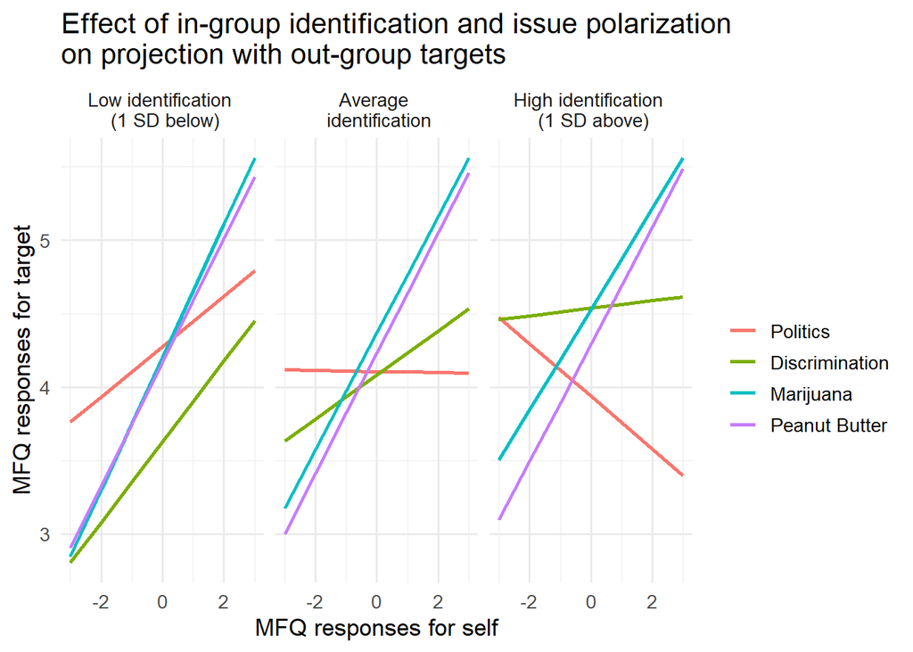

```r
#setting figure height and width
knitr::opts_chunk$set(fig.width = 10, fig.height = 10)

#running the plot
ggplot(summary.3way, aes(x = MFQSelf_c,
                         y = lsmean,
                         color = as.factor(Condition))) +
  facet_grid(.~Identification_c,
             labeller = labeller(Identification_c=Ident_label)) +
  geom_line(size=1) +
  xlab("MFQ responses for self") +
  ylab("MFQ responses for target") +
  scale_color_discrete("", breaks = c(1,2,3,4),
                       labels = c ("Politics",
                                   "Discrimination",
                                   "Marijuana",
                                   "Peanut Butter")) +
  ggtitle("Effect of in-group identification and issue polarization \non projection with out-group targets") +
   theme(legend.position = "bottom",
         legend.text = element_text(size = 11)) +
  theme_minimal(base_size = 13)
```

### Model without color for publication

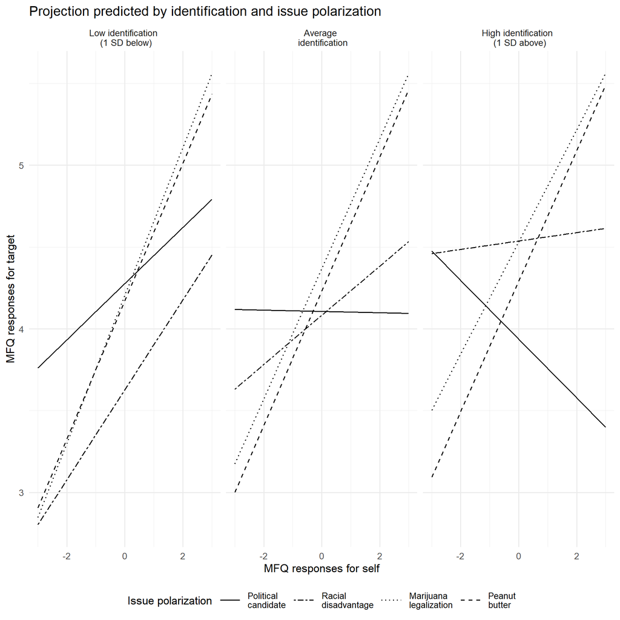

```r
#running the plot

ggpreview <- function(...) {
  fname <- tempfile(fileext = ".png")
  ggsave(filename = fname, ...)
  system2("open", fname)
  invisible(NULL)
}

knitr::opts_chunk$set(fig.width = 8, fig.height = 6)

ggplot(summary.3way, aes(x = MFQSelf_c,
                         y = lsmean,
                         group = as.factor(Condition))) +
  facet_grid(.~Identification_c,
             labeller = labeller(Identification_c = Ident_label)) +
  geom_line(size = .7, aes(linetype = Condition)) +
  xlab("MFQ responses for self") +
  ylab("MFQ responses for target") +
  scale_linetype_manual("Issue polarization",
                        breaks = c(1,2,3,4),
                        labels = c ("Political\ncandidate",
                                   "Racial\ndisadvantage",
                                   "Marijuana\nlegalization",
                                   "Peanut\nbutter"),
                        values = c("solid",
                                   "twodash",
                                   "dotted",
                                   "dashed")) +
  ggtitle("Projection predicted by identification and issue polarization") +
  theme_minimal(base_size = 13) +
  theme(legend.text = element_text(size = 10),
        legend.key.width = unit(1, "cm"),
        legend.position = "bottom")
```

```r
ggpreview(width = 8, height = 6, units = "in")
```

## Plot for two-way

### Plot with color

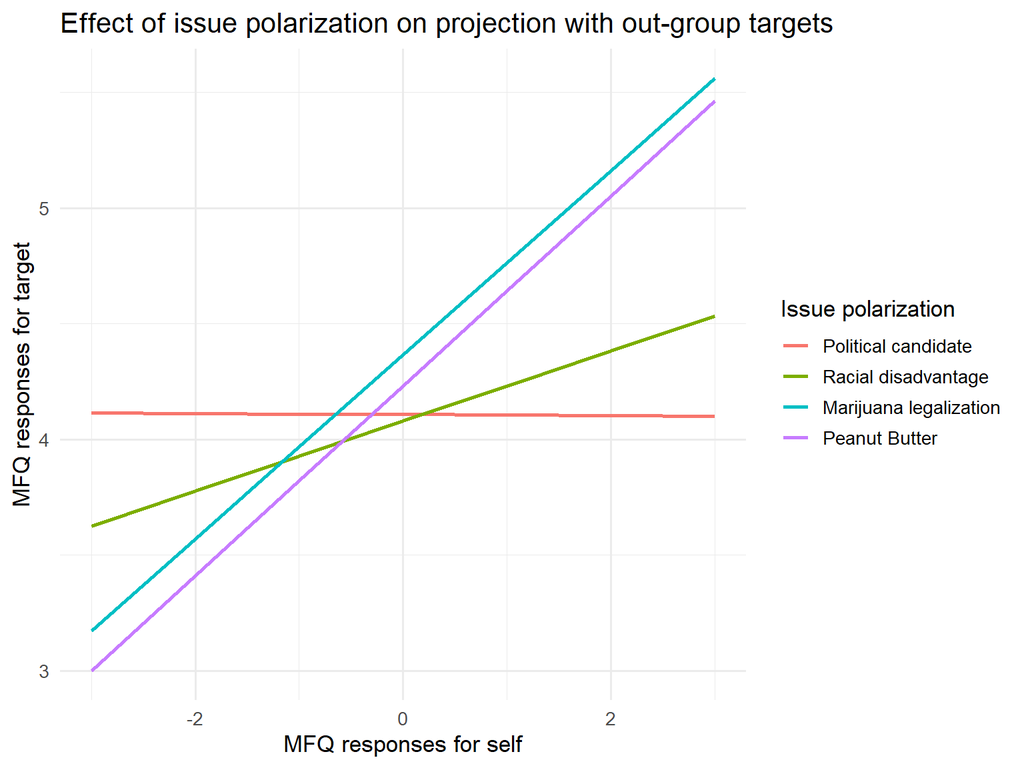

```r
knitr::opts_chunk$set(fig.width = 10, fig.height = 10)
ggplot(summary.2way.cond, aes(x = MFQSelf_c,
                              y = lsmean,
                              color = as.factor(Condition)))+
  geom_line(size = 1) +
  xlab("MFQ responses for self") +
  ylab("MFQ responses for target") +
  scale_color_discrete("Issue polarization",
                       breaks = c(1,2,3,4),
                       labels = c("Political candidate",
                                  "Racial disadvantage",
                                  "Marijuana legalization",
                                  "Peanut Butter")) +
  ggtitle("Effect of issue polarization on projection with out-group targets") +
  theme(legend.position = "bottom",
        legend.text = element_text(size = 11)) +
  theme_minimal(base_size = 13)
```

### Plot without color for publication

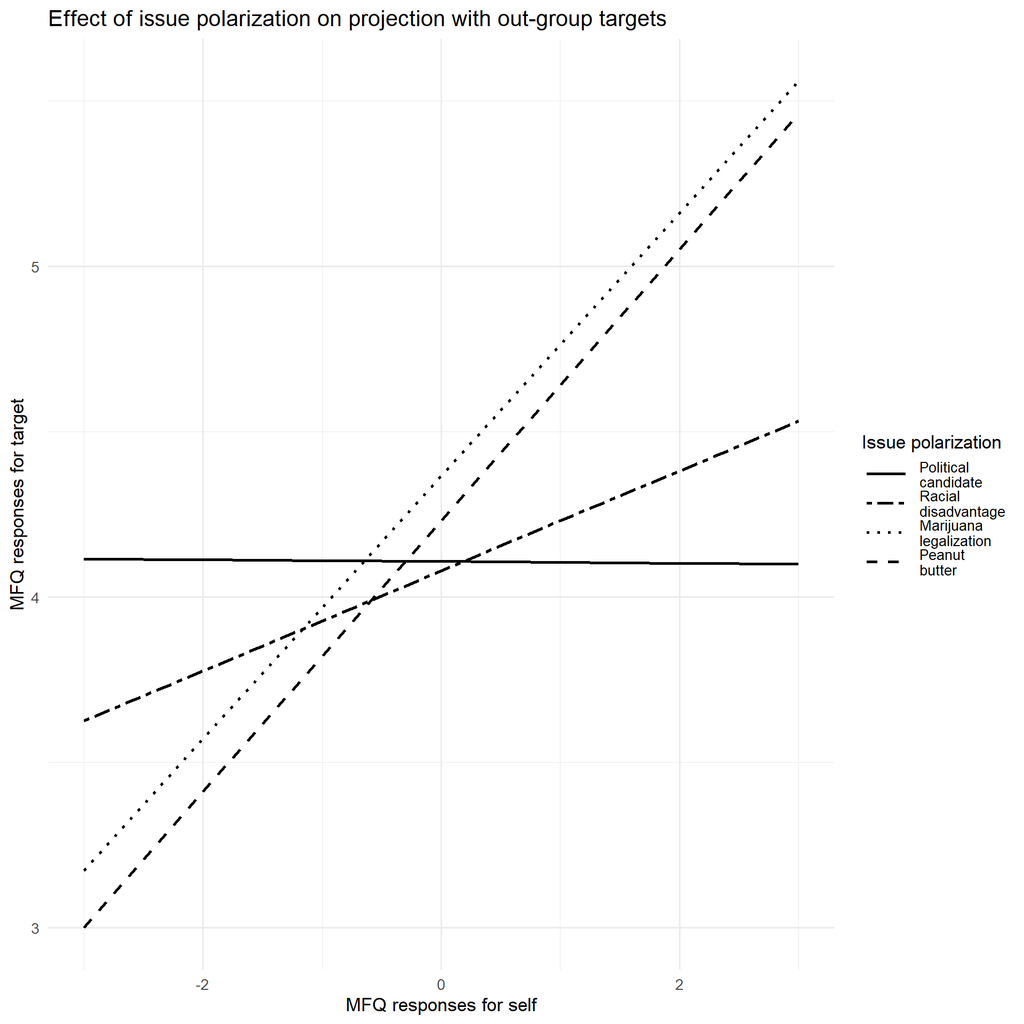

```r
knitr::opts_chunk$set(fig.width = 8, fig.height = 6)

ggplot(summary.2way.cond, aes(x = MFQSelf_c,
                              y = lsmean,
                              group = as.factor(Condition)))+
  geom_line(size = 1, aes(linetype = Condition)) +
  xlab("MFQ responses for self") +
  ylab("MFQ responses for target") +
  scale_linetype_manual("Issue polarization",
                      breaks = c(1,2,3,4),
                      labels = c("Political\ncandidate",
                                  "Racial\ndisadvantage",
                                  "Marijuana\nlegalization",
                                  "Peanut\nbutter"),
                       values = c("solid",
                                   "twodash",
                                   "dotted",
                                   "dashed")) +
  ggtitle("Effect of issue polarization on projection with out-group targets") +
  theme_minimal(base_size = 13) +
  theme(legend.text = element_text(size = 10),
        legend.key.width = unit(1.2, "cm"))
```

```r
ggpreview(width = 8, height = 6, units = "in")
```

## Plot for main effect of in-group identification

### Color plot

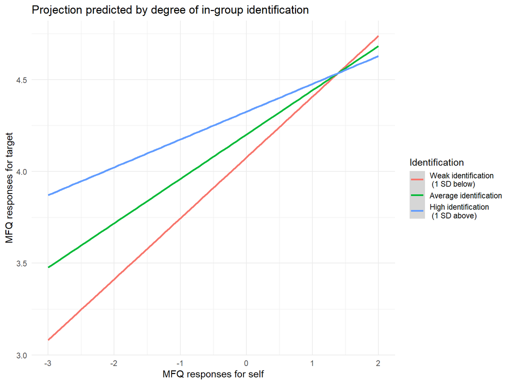

```r
knitr::opts_chunk$set(fig.width = 8, fig.height = 6)

ggplot(effects_ident_main, aes(MFQSelf_c,
                               fit,
                               group = Identification,
                               color = Identification)) +
  geom_smooth(method = "lm") +
  scale_color_discrete("Identification", breaks = c(-1.19, 0, 1.19),
                       labels =c ("Weak identification \n (1 SD below)",
                                  "Average identification",
                                  "High identification \n (1 SD above)")) +
  theme_minimal() +
  labs(title = "Projection predicted by degree of in-group identification",
       x = "MFQ responses for self",
       y = "MFQ responses for target")
```

### Plot without color for publication

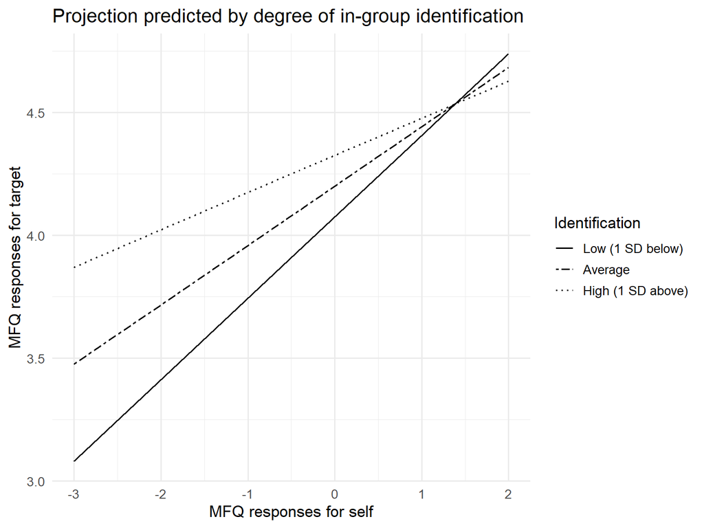

```r
knitr::opts_chunk$set(fig.width = 8, fig.height = 6)

ggplot(effects_ident_main, aes(MFQSelf_c,
                               fit,
                               group = Identification)) +
  geom_line(aes(linetype = Identification), size = .7) +
  scale_linetype_manual("Identification",
                       breaks = c(-1.19, 0, 1.19),
                       labels = c ("Low (1 SD below)",
                                  "Average ",
                                  "High (1 SD above)"),
                        values = c("solid",
                                   "twodash",
                                   "dotted")) +
  theme_minimal(base_size = 13) +
  labs(title = "Projection predicted by degree of in-group identification",
       x = "MFQ responses for self",
       y = "MFQ responses for target")
```

```r
ggpreview(width = 8, height = 6, units = "in")
```